# 重賞レース予測レポート【毎時自動更新中】

作成日時: 2025/10/12 16:06:58

☞ [マニュアル(pdf)](https://ryutoro-galois.github.io/keiba-predictor/manual/manual.pdf)

☞ 過去5年の同一レース結果: [2024年](https://ryutoro-galois.github.io/keiba-predictor/report/PredResult_2024y_raceDate_20241005_20241006.html), [2023年](https://ryutoro-galois.github.io/keiba-predictor/report/PredResult_2023y_raceDate_20231007_20231009.html), [2022年](https://ryutoro-galois.github.io/keiba-predictor/report/PredResult_2022y_raceDate_20221008_20221010.html), [2021年](https://ryutoro-galois.github.io/keiba-predictor/report/PredResult_2021y_raceDate_20211009_20211010.html), [2020年](https://ryutoro-galois.github.io/keiba-predictor/report/PredResult_2020y_raceDate_20201010_20201011.html)

☞ 過去4週間の別レース結果: [1週前(10/5)](https://ryutoro-galois.github.io/keiba-predictor/report/PredResult_2025y_raceDate_20251005_20251005.html), [2週前(9/27-28)](https://ryutoro-galois.github.io/keiba-predictor/report/PredResult_2025y_raceDate_20250927_20250928.html), [3週前(9/20-21)](https://ryutoro-galois.github.io/keiba-predictor/report/PredResult_2025y_raceDate_20250920_20250921.html), [4週前(9/13-15)](https://ryutoro-galois.github.io/keiba-predictor/report/PredResult_2025y_raceDate_20250913_20250915.html)

☞ netkeiba: [サウジアラビアRC(GⅢ)](https://race.netkeiba.com/race/shutuba.html?race_id=202505040311&rf=race_list), [アイルランドトロフィー(GⅡ)](https://race.netkeiba.com/race/shutuba.html?race_id=202505040411&rf=race_list), [スワンステークス(GⅡ)](https://race.netkeiba.com/race/shutuba.html?race_id=202508030511&rf=race_list)

## 0. 推し馬予測 (AI予測)

### 【サウジアラビアRC(GⅢ) 2025/10/11(土)】

- 本命(◎): 1-3着内確率(勝負強さ)が1位の馬
- 対抗(◯): 1-3着内確率が2-N位(20%程度以上)の中で予測タイムが最も速い馬
- 3番手(▲): 1-3着内確率が2-N位(20%程度以上)のでダークホース確率が最も高い馬
- 穴: ダークホース確率が上位1-M位(40%程度以上)の中で1-3着内確率が最も高い馬

| 推し馬 | 枠番 | 馬番 | 人気 | オッズ | 馬名 | 騎手 | 調教師 | 予測タイム(sec) | 1_順位 | 1-3着内確率(%) | 2_順位 | ﾀﾞｰｸﾎｰｽ確率(%) | 3_順位 |
| --- | --- | --- | --- | --- | --- | --- | --- | --- | --- | --- | --- | --- | --- |
| 本命(◎) | 6 | 6 | 2 | 3.6 | エコロアルバ | 坂井瑠星 | 田村康仁 | 101.6 | 7.0 | 22.8 | 1 | 1.3 | 7 |
| 対抗(◯) | 5 | 5 | 1 | 1.9 | ゾロアストロ | Ｃ．ルメール | 宮田敬介 | 92.7 | 1.0 | 16.8 | 3 | 0.4 | 8 |
| 3番手(▲) | 1 | 1 | 7 | 53.4 | ガリレア | 杉原誠人 | 清水英克 | 101.6 | 4.5 | 8.4 | 6 | 43.0 | 2 |
| 穴 | 2 | 2 | 8 | 60.1 | マーゴットブロー | 荻野極 | 伊坂重信 | 101.6 | 4.5 | 7.9 | 8 | 43.7 | 1 |

### 【アイルランドトロフィー(GⅡ) 2025/10/12(日)】

- 本命(◎): 1-3着内確率(勝負強さ)が1位の馬
- 対抗(◯): 1-3着内確率が2-N位(20%程度以上)の中で予測タイムが最も速い馬
- 3番手(▲): 1-3着内確率が2-N位(20%程度以上)のでダークホース確率が最も高い馬
- 穴: ダークホース確率が上位1-M位(40%程度以上)の中で1-3着内確率が最も高い馬

| 推し馬 | 枠番 | 馬番 | 人気 | オッズ | 馬名 | 騎手 | 調教師 | 予測タイム(sec) | 1_順位 | 1-3着内確率(%) | 2_順位 | ﾀﾞｰｸﾎｰｽ確率(%) | 3_順位 |
| --- | --- | --- | --- | --- | --- | --- | --- | --- | --- | --- | --- | --- | --- |
| 本命(◎) | 1 | 1 | 2 | 4.4 | アドマイヤマツリ | 武豊 | 宮田敬介 | 110.4 | 5 | 58.1 | 1 | 0.6 | 14 |
| 対抗(◯) | 4 | 8 | 1 | 3.9 | ボンドガール | Ｃ．ルメール | 手塚貴久 | 105.9 | 1 | 33.2 | 3 | 0.7 | 13 |
| 3番手(▲) | 1 | 2 | 6 | 13.2 | アンゴラブラック | 戸崎圭太 | 尾関知人 | 109.9 | 3 | 31.6 | 5 | 1.7 | 10 |
| 穴 | 3 | 6 | 12 | 58.2 | セフィロ | 横山和生 | 菊沢隆徳 | 110.0 | 4 | 11.7 | 11 | 44.2 | 2 |

### 【スワンステークス(GⅡ) 2025/10/13(月)】

- 本命(◎): 1-3着内確率(勝負強さ)が1位の馬
- 対抗(◯): 1-3着内確率が2-N位(20%程度以上)の中で予測タイムが最も速い馬
- 3番手(▲): 1-3着内確率が2-N位(20%程度以上)のでダークホース確率が最も高い馬
- 穴: ダークホース確率が上位1-M位(40%程度以上)の中で1-3着内確率が最も高い馬

| 推し馬 | 枠番 | 馬番 | 人気 | オッズ | 馬名 | 騎手 | 調教師 | 予測タイム(sec) | 1_順位 | 1-3着内確率(%) | 2_順位 | ﾀﾞｰｸﾎｰｽ確率(%) | 3_順位 |
| --- | --- | --- | --- | --- | --- | --- | --- | --- | --- | --- | --- | --- | --- |
| 本命(◎) | 4 | 8 | 2 | 6.1 | ワールズエンド | 戸崎圭太 | 池添学 | 82.5 | 6 | 45.6 | 1 | 0.6 | 18 |
| 対抗(◯) | 7 | 14 | 1 | 3.3 | アドマイヤズーム | 坂井瑠星 | 友道康夫 | 79.4 | 1 | 21.9 | 4 | 0.6 | 17 |
| 3番手(▲) | 8 | 17 | 10 | 22.9 | アサカラキング | 岩田康誠 | 斎藤誠 | 86.4 | 14 | 20.3 | 7 | 36.9 | 6 |
| 穴 | 2 | 4 | 12 | 38.1 | ワイドラトゥール | 北村友一 | 藤原英昭 | 82.3 | 3 | 14.5 | 10 | 42.5 | 4 |

## 1. 予測チャート (タイム/勝負強さ)

### 【サウジアラビアRC(GⅢ)】

2025/10/11(土), 05_東京, 芝左1600m

[interactive chart not shown]

### 【アイルランドトロフィー(GⅡ)】

2025/10/12(日), 05_東京, 芝1800m

[interactive chart not shown]

### 【スワンステークス(GⅡ)】

2025/10/13(月), 08_京都, 芝右外1400m

[interactive chart not shown]

## 2. オッズモニタリング (毎時)

### 【サウジアラビアRカップ】

[interactive chart not shown]

### 【アイルランドトロフィー】

[interactive chart not shown]

### 【スワンステークス】

[interactive chart not shown]

## 3. 出馬表

### 【サウジアラビアRカップ 2025/10/11(土) 】

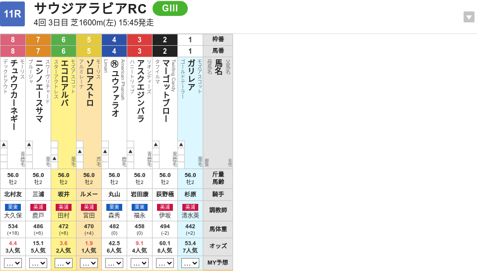

### 【アイルランドトロフィー 2025/10/12(日) 】

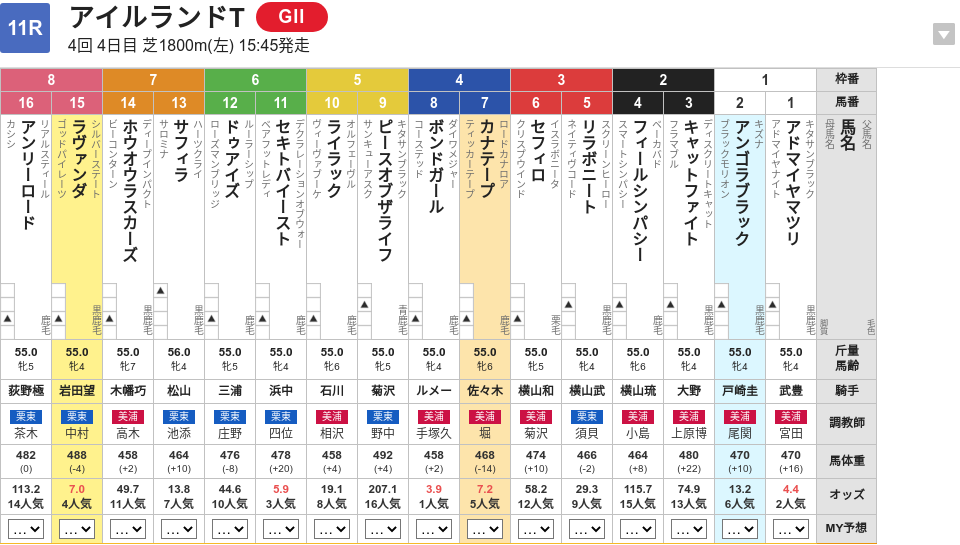

### 【スワンステークス 2025/10/13(月) 】

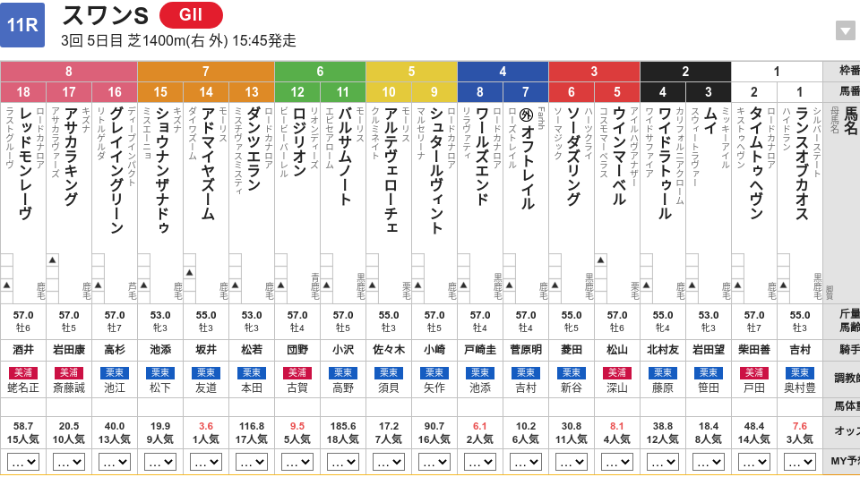

## 4. 単勝予測結果

### 【サウジアラビアRC(GⅢ) 2025/10/11(土)】

| 枠番 | 馬番 | 人気 | オッズ | 馬名 | 騎手 | 調教師 | 予測タイム(sec) | 1_順位 | 1-3着内確率(%) | 2_順位 | ﾀﾞｰｸﾎｰｽ確率(%) | 3_順位 |
| --- | --- | --- | --- | --- | --- | --- | --- | --- | --- | --- | --- | --- |
| 1 | 1 | 7 | 53.4 | ガリレア | 杉原誠人 | 清水英克 | 101.6 | 4.5 | 8.4 | 6 | 43.0 | 2 |
| 2 | 2 | 8 | 60.1 | マーゴットブロー | 荻野極 | 伊坂重信 | 101.6 | 4.5 | 7.9 | 8 | 43.7 | 1 |
| 3 | 3 | 4 | 9.1 | アスクエジンバラ | 岩田康誠 | 福永祐一 | 101.6 | 4.5 | 11.8 | 4 | 1.9 | 5 |
| 4 | 4 | 6 | 42.5 | ユウファラオ | 丸山元気 | 森秀行 | 101.6 | 4.5 | 8.7 | 5 | 38.3 | 3 |
| 5 | 5 | 1 | 1.9 | ゾロアストロ | Ｃ．ルメール | 宮田敬介 | 92.7 | 1.0 | 16.8 | 3 | 0.4 | 8 |
| 6 | 6 | 2 | 3.6 | エコロアルバ | 坂井瑠星 | 田村康仁 | 101.6 | 7.0 | 22.8 | 1 | 1.3 | 7 |
| 7 | 7 | 5 | 15.1 | ニシノエースサマ | 三浦皇成 | 鹿戸雄一 | 100.8 | 2.0 | 8.1 | 7 | 28.9 | 4 |
| 8 | 8 | 3 | 4.4 | チュウワカーネギー | 北村友一 | 大久保龍志 | 101.7 | 8.0 | 19.7 | 2 | 1.6 | 6 |

### 【アイルランドトロフィー(GⅡ) 2025/10/12(日)】

| 枠番 | 馬番 | 人気 | オッズ | 馬名 | 騎手 | 調教師 | 予測タイム(sec) | 1_順位 | 1-3着内確率(%) | 2_順位 | ﾀﾞｰｸﾎｰｽ確率(%) | 3_順位 |
| --- | --- | --- | --- | --- | --- | --- | --- | --- | --- | --- | --- | --- |
| 1 | 1 | 2 | 4.4 | アドマイヤマツリ | 武豊 | 宮田敬介 | 110.4 | 5 | 58.1 | 1 | 0.6 | 14 |
| 1 | 2 | 6 | 13.2 | アンゴラブラック | 戸崎圭太 | 尾関知人 | 109.9 | 3 | 31.6 | 5 | 1.7 | 10 |
| 2 | 3 | 13 | 74.9 | キャットファイト | 大野拓弥 | 上原博之 | 115.5 | 15 | 10.7 | 13 | 30.6 | 5 |
| 2 | 4 | 15 | 115.7 | フィールシンパシー | 横山琉人 | 小島茂之 | 111.7 | 7 | 11.4 | 12 | 61.4 | 1 |
| 3 | 5 | 9 | 29.3 | リラボニート | 横山武史 | 須貝尚介 | 109.9 | 2 | 15.2 | 9 | 36.8 | 3 |
| 3 | 6 | 12 | 58.2 | セフィロ | 横山和生 | 菊沢隆徳 | 110.0 | 4 | 11.7 | 11 | 44.2 | 2 |
| 4 | 7 | 5 | 7.2 | カナテープ | 佐々木大輔 | 堀宣行 | 112.8 | 8 | 22.5 | 6 | 0.6 | 16 |
| 4 | 8 | 1 | 3.9 | ボンドガール | Ｃ．ルメール | 手塚貴久 | 105.9 | 1 | 33.2 | 3 | 0.7 | 13 |
| 5 | 9 | 16 | 207.1 | ピースオブザライフ | 菊沢一樹 | 野中賢二 | 112.9 | 10 | 2.6 | 16 | 10.8 | 8 |
| 5 | 10 | 8 | 19.1 | ライラック | 石川裕紀人 | 相沢郁 | 114.3 | 14 | 13.6 | 10 | 1.4 | 11 |

[output cut: 6 more lines]

### 【スワンステークス(GⅡ) 2025/10/13(月)】

| 枠番 | 馬番 | 人気 | オッズ | 馬名 | 騎手 | 調教師 | 予測タイム(sec) | 1_順位 | 1-3着内確率(%) | 2_順位 | ﾀﾞｰｸﾎｰｽ確率(%) | 3_順位 |
| --- | --- | --- | --- | --- | --- | --- | --- | --- | --- | --- | --- | --- |
| 1 | 1 | 3 | 8.1 | ランスオブカオス | 吉村誠之助 | 奥村豊 | 82.3 | 4 | 34.6 | 2 | 1.2 | 15 |
| 1 | 2 | 14 | 49.2 | タイムトゥヘヴン | 柴田善臣 | 戸田博文 | 87.3 | 17 | 6.6 | 15 | 14.2 | 8 |
| 2 | 3 | 8 | 19.2 | ムイ | 岩田望来 | 笹田和秀 | 82.4 | 5 | 21.3 | 6 | 1.7 | 11 |
| 2 | 4 | 12 | 38.1 | ワイドラトゥール | 北村友一 | 藤原英昭 | 82.3 | 3 | 14.5 | 10 | 42.5 | 4 |
| 3 | 5 | 5 | 9.2 | ウインマーベル | 松山弘平 | 深山雅史 | 86.7 | 15 | 12.2 | 12 | 1.3 | 14 |
| 3 | 6 | 11 | 32.4 | ソーダズリング | 菱田裕二 | 新谷功一 | 86.3 | 12 | 9.3 | 13 | 21.4 | 7 |
| 4 | 7 | 6 | 10.0 | オフトレイル | 菅原明良 | 吉村圭司 | 83.8 | 9 | 25.7 | 3 | 1.5 | 13 |
| 4 | 8 | 2 | 6.1 | ワールズエンド | 戸崎圭太 | 池添学 | 82.5 | 6 | 45.6 | 1 | 0.6 | 18 |
| 5 | 9 | 16 | 89.1 | シュタールヴィント | 小崎綾也 | 矢作芳人 | 86.9 | 16 | 2.7 | 18 | 42.9 | 3 |
| 5 | 10 | 7 | 16.8 | アルテヴェローチェ | 佐々木大輔 | 須貝尚介 | 82.2 | 2 | 21.5 | 5 | 1.7 | 12 |

[output cut: 8 more lines]

## 5. 人気と着順の乖離率推移

### 【サウジアラビアRC_2016y_2019y】

[interactive chart not shown]

### 【サウジアラビアRC_2016y_2019y】

| No | 開催年 | 不整合率(%) | 頭数 | 人気別着順(1-3位) | 人気別着順(全体) |
| --- | --- | --- | --- | --- | --- |
| 4 | 2019 | 8.8 | 9頭 | 1-2-3 | 1\|2\|3\|6\|5\|7\|9\|4\|8 |
| 3 | 2018 | 35.2 | 8頭 | 1-7-4 | 1\|7\|4\|3\|2\|8\|5\|6 |
| 2 | 2017 | 22.5 | 18頭 | 2-1-6 | 2\|1\|6\|3\|5\|4\|9\|7\|12\|11\|13\|16\|14\|15\|10\|17\|8\|18 |
| 1 | 2016 | 53.1 | 9頭 | 3-2-1 | 3\|2\|1\|6\|5\|8\|4\|7\|9 |

## 6. 1-3番人気馬の着順分類予測

### 【サウジアラビアRC】

| 分類 | 凡例 | 発生確率(%) | 当該レース | 当該レースランク | 直近1年間 |
| --- | --- | --- | --- | --- | --- |
| 1: 1番人気のみ (1_pop1) | 1 \| * \| * | 16.8 | 1.68 | 1.68 | 0.00 |
| 4: 1,2番人気のみ (4_pop12) | 1 \| 2 \| * | 16.2 | 1.62 | 1.62 | 0.32 |
| 5: 1,3番人気のみ (5_pop13) | 1 \| 3 \| * | 13.7 | 0.00 | 0.00 | 0.00 |
| 8: 1,2,3番人気すべて着外 (8_darkhorse) | * \| * \| * | 13.7 | 0.00 | 0.00 | 0.00 |
| 7: 1,2,3番人気すべて着内 (7_pop123) | 1 \| 2 \| 3 | 11.4 | 0.14 | 0.14 | 0.23 |
| 2: 2番人気のみ (2_pop2) | 2 \| * \| * | 9.7 | 0.00 | 0.00 | 0.00 |
| 6: 2,3番人気のみ (6_pop23) | 2 \| 3 \| * | 9.5 | 0.00 | 0.00 | 0.00 |
| 3: 3番人気のみ (3_pop3) | 3 \| * \| * | 9.1 | 0.00 | 0.00 | 0.00 |

## 7. 3連複予測結果

### 【サウジアラビアRC(GⅢ) 2025/10/11(土)】

| 分類 | 馬番 | 枠番 | 人気 | 平均予測タイム(sec) | 1-3着内確率(%) | ﾀﾞｰｸﾎｰｽ確率(%) | 馬名 | 騎手 | 調教師 |
| --- | --- | --- | --- | --- | --- | --- | --- | --- | --- |
| 7: 1,2,3番人気すべて着内 (7_pop123) | 5-6-8 | 5-6-8 | 1-2-3 | 98.67 | 0.75 | 0.00 | ゾロアストロ \| エコロアルバ \| チュウワカーネギー | Ｃ．ルメール \| 坂井瑠星 \| 北村友一 | 宮田敬介 \| 田村康仁 \| 大久保龍志 |
| 6: 2,3番人気のみ (6_pop23) | 6-8-3 | 6-8-3 | 2-3-4 | 101.63 | 0.53 | 0.00 | エコロアルバ \| チュウワカーネギー \| アスクエジンバラ | 坂井瑠星 \| 北村友一 \| 岩田康誠 | 田村康仁 \| 大久保龍志 \| 福永祐一 |
| 4: 1,2番人気のみ (4_pop12) | 5-6-3 | 5-6-3 | 1-2-4 | 98.63 | 0.45 | 0.00 | ゾロアストロ \| エコロアルバ \| アスクエジンバラ | Ｃ．ルメール \| 坂井瑠星 \| 岩田康誠 | 宮田敬介 \| 田村康仁 \| 福永祐一 |
| 6: 2,3番人気のみ (6_pop23) | 6-8-4 | 6-8-4 | 2-3-6 | 101.63 | 0.39 | 0.01 | エコロアルバ \| チュウワカーネギー \| ユウファラオ | 坂井瑠星 \| 北村友一 \| 丸山元気 | 田村康仁 \| 大久保龍志 \| 森秀行 |
| 5: 1,3番人気のみ (5_pop13) | 5-8-3 | 5-8-3 | 1-3-4 | 98.67 | 0.39 | 0.00 | ゾロアストロ \| チュウワカーネギー \| アスクエジンバラ | Ｃ．ルメール \| 北村友一 \| 岩田康誠 | 宮田敬介 \| 大久保龍志 \| 福永祐一 |
| 6: 2,3番人気のみ (6_pop23) | 6-8-1 | 6-8-1 | 2-3-7 | 101.63 | 0.38 | 0.01 | エコロアルバ \| チュウワカーネギー \| ガリレア | 坂井瑠星 \| 北村友一 \| 杉原誠人 | 田村康仁 \| 大久保龍志 \| 清水英克 |
| 6: 2,3番人気のみ (6_pop23) | 6-8-7 | 6-8-7 | 2-3-5 | 101.37 | 0.37 | 0.01 | エコロアルバ \| チュウワカーネギー \| ニシノエースサマ | 坂井瑠星 \| 北村友一 \| 三浦皇成 | 田村康仁 \| 大久保龍志 \| 鹿戸雄一 |
| 6: 2,3番人気のみ (6_pop23) | 6-8-2 | 6-8-2 | 2-3-8 | 101.63 | 0.35 | 0.01 | エコロアルバ \| チュウワカーネギー \| マーゴットブロー | 坂井瑠星 \| 北村友一 \| 荻野極 | 田村康仁 \| 大久保龍志 \| 伊坂重信 |
| 4: 1,2番人気のみ (4_pop12) | 5-6-4 | 5-6-4 | 1-2-6 | 98.63 | 0.33 | 0.00 | ゾロアストロ \| エコロアルバ \| ユウファラオ | Ｃ．ルメール \| 坂井瑠星 \| 丸山元気 | 宮田敬介 \| 田村康仁 \| 森秀行 |
| 4: 1,2番人気のみ (4_pop12) | 5-6-1 | 5-6-1 | 1-2-7 | 98.63 | 0.32 | 0.00 | ゾロアストロ \| エコロアルバ \| ガリレア | Ｃ．ルメール \| 坂井瑠星 \| 杉原誠人 | 宮田敬介 \| 田村康仁 \| 清水英克 |

[output cut: 46 more lines]

### 【アイルランドトロフィー(GⅡ) 2025/10/12(日)】

| 分類 | 馬番 | 枠番 | 人気 | 平均予測タイム(sec) | 1-3着内確率(%) | ﾀﾞｰｸﾎｰｽ確率(%) | 馬名 | 騎手 | 調教師 |
| --- | --- | --- | --- | --- | --- | --- | --- | --- | --- |
| 4: 1,2番人気のみ (4_pop12) | 8-1-15 | 4-1-8 | 1-2-4 | 109.73 | 7.66 | 0.00 | ボンドガール \| アドマイヤマツリ \| ラヴァンダ | Ｃ．ルメール \| 武豊 \| 岩田望来 | 手塚貴久 \| 宮田敬介 \| 中村直也 |
| 6: 2,3番人気のみ (6_pop23) | 1-11-15 | 1-6-8 | 2-3-4 | 112.13 | 7.35 | 0.00 | アドマイヤマツリ \| セキトバイースト \| ラヴァンダ | 武豊 \| 浜中俊 \| 岩田望来 | 宮田敬介 \| 四位洋文 \| 中村直也 |
| 2: 2番人気のみ (2_pop2) | 1-15-2 | 1-8-1 | 2-4-6 | 111.07 | 7.28 | 0.00 | アドマイヤマツリ \| ラヴァンダ \| アンゴラブラック | 武豊 \| 岩田望来 \| 戸崎圭太 | 宮田敬介 \| 中村直也 \| 尾関知人 |
| 7: 1,2,3番人気すべて着内 (7_pop123) | 8-1-11 | 4-1-6 | 1-2-3 | 109.80 | 6.14 | 0.00 | ボンドガール \| アドマイヤマツリ \| セキトバイースト | Ｃ．ルメール \| 武豊 \| 浜中俊 | 手塚貴久 \| 宮田敬介 \| 四位洋文 |
| 4: 1,2番人気のみ (4_pop12) | 8-1-2 | 4-1-1 | 1-2-6 | 108.73 | 6.09 | 0.00 | ボンドガール \| アドマイヤマツリ \| アンゴラブラック | Ｃ．ルメール \| 武豊 \| 戸崎圭太 | 手塚貴久 \| 宮田敬介 \| 尾関知人 |
| 6: 2,3番人気のみ (6_pop23) | 1-11-2 | 1-6-1 | 2-3-6 | 111.13 | 5.84 | 0.00 | アドマイヤマツリ \| セキトバイースト \| アンゴラブラック | 武豊 \| 浜中俊 \| 戸崎圭太 | 宮田敬介 \| 四位洋文 \| 尾関知人 |
| 2: 2番人気のみ (2_pop2) | 1-15-7 | 1-8-4 | 2-4-5 | 112.03 | 5.19 | 0.00 | アドマイヤマツリ \| ラヴァンダ \| カナテープ | 武豊 \| 岩田望来 \| 佐々木大輔 | 宮田敬介 \| 中村直也 \| 堀宣行 |
| 4: 1,2番人気のみ (4_pop12) | 8-1-7 | 4-1-4 | 1-2-5 | 109.70 | 4.34 | 0.00 | ボンドガール \| アドマイヤマツリ \| カナテープ | Ｃ．ルメール \| 武豊 \| 佐々木大輔 | 手塚貴久 \| 宮田敬介 \| 堀宣行 |
| 2: 2番人気のみ (2_pop2) | 1-15-13 | 1-8-7 | 2-4-7 | 111.47 | 4.28 | 0.00 | アドマイヤマツリ \| ラヴァンダ \| サフィラ | 武豊 \| 岩田望来 \| 松山弘平 | 宮田敬介 \| 中村直也 \| 池添学 |
| 5: 1,3番人気のみ (5_pop13) | 8-11-15 | 4-6-8 | 1-3-4 | 110.63 | 4.20 | 0.00 | ボンドガール \| セキトバイースト \| ラヴァンダ | Ｃ．ルメール \| 浜中俊 \| 岩田望来 | 手塚貴久 \| 四位洋文 \| 中村直也 |

[output cut: 550 more lines]

### 【スワンステークス(GⅡ) 2025/10/13(月)】

| 分類 | 馬番 | 枠番 | 人気 | 平均予測タイム(sec) | 1-3着内確率(%) | ﾀﾞｰｸﾎｰｽ確率(%) | 馬名 | 騎手 | 調教師 |
| --- | --- | --- | --- | --- | --- | --- | --- | --- | --- |
| 6: 2,3番人気のみ (6_pop23) | 8-1-7 | 4-1-4 | 2-3-6 | 82.87 | 4.06 | 0.00 | ワールズエンド \| ランスオブカオス \| オフトレイル | 戸崎圭太 \| 吉村誠之助 \| 菅原明良 | 池添学 \| 奥村豊 \| 吉村圭司 |
| 7: 1,2,3番人気すべて着内 (7_pop123) | 14-8-1 | 7-4-1 | 1-2-3 | 81.40 | 3.45 | 0.00 | アドマイヤズーム \| ワールズエンド \| ランスオブカオス | 坂井瑠星 \| 戸崎圭太 \| 吉村誠之助 | 友道康夫 \| 池添学 \| 奥村豊 |
| 6: 2,3番人気のみ (6_pop23) | 8-1-10 | 4-1-5 | 2-3-7 | 82.33 | 3.39 | 0.00 | ワールズエンド \| ランスオブカオス \| アルテヴェローチェ | 戸崎圭太 \| 吉村誠之助 \| 佐々木大輔 | 池添学 \| 奥村豊 \| 須貝尚介 |
| 6: 2,3番人気のみ (6_pop23) | 8-1-3 | 4-1-2 | 2-3-8 | 82.40 | 3.36 | 0.00 | ワールズエンド \| ランスオブカオス \| ムイ | 戸崎圭太 \| 吉村誠之助 \| 岩田望来 | 池添学 \| 奥村豊 \| 笹田和秀 |
| 6: 2,3番人気のみ (6_pop23) | 8-1-17 | 4-1-8 | 2-3-10 | 83.73 | 3.20 | 0.00 | ワールズエンド \| ランスオブカオス \| アサカラキング | 戸崎圭太 \| 吉村誠之助 \| 岩田康誠 | 池添学 \| 奥村豊 \| 斎藤誠 |
| 6: 2,3番人気のみ (6_pop23) | 8-1-12 | 4-1-6 | 2-3-4 | 83.70 | 3.17 | 0.00 | ワールズエンド \| ランスオブカオス \| ロジリオン | 戸崎圭太 \| 吉村誠之助 \| 団野大成 | 池添学 \| 奥村豊 \| 古賀慎明 |
| 4: 1,2番人気のみ (4_pop12) | 14-8-7 | 7-4-4 | 1-2-6 | 81.90 | 2.56 | 0.00 | アドマイヤズーム \| ワールズエンド \| オフトレイル | 坂井瑠星 \| 戸崎圭太 \| 菅原明良 | 友道康夫 \| 池添学 \| 吉村圭司 |
| 2: 2番人気のみ (2_pop2) | 8-7-10 | 4-4-5 | 2-6-7 | 82.83 | 2.52 | 0.00 | ワールズエンド \| オフトレイル \| アルテヴェローチェ | 戸崎圭太 \| 菅原明良 \| 佐々木大輔 | 池添学 \| 吉村圭司 \| 須貝尚介 |
| 2: 2番人気のみ (2_pop2) | 8-7-3 | 4-4-2 | 2-6-8 | 82.90 | 2.49 | 0.00 | ワールズエンド \| オフトレイル \| ムイ | 戸崎圭太 \| 菅原明良 \| 岩田望来 | 池添学 \| 吉村圭司 \| 笹田和秀 |
| 2: 2番人気のみ (2_pop2) | 8-7-17 | 4-4-8 | 2-6-10 | 84.23 | 2.37 | 0.00 | ワールズエンド \| オフトレイル \| アサカラキング | 戸崎圭太 \| 菅原明良 \| 岩田康誠 | 池添学 \| 吉村圭司 \| 斎藤誠 |

[output cut: 806 more lines]

## 8. 直近の全レース情報

| No | 日付 | 競馬場 | R | 発走 | レース名 | 距離 | 頭数 | URL(netkeiba) |
| --- | --- | --- | --- | --- | --- | --- | --- | --- |
| 7 | 2025/10/12(日) | 05_東京 | 9R | 14:30 | 鷹巣山特別 | 1600 | 19頭 | https://race.netkeiba.com/race/shutuba.html?race_id=202505040409&amp;rf=race_list |
| 8 | 2025/10/12(日) | 05_東京 | 10R | 15:05 | テレビ静岡賞 | 1400 | 23頭 | https://race.netkeiba.com/race/shutuba.html?race_id=202505040410&amp;rf=race_list |
| 9 | 2025/10/12(日) | 05_東京 | 11R | 15:45 | アイルランドトロフィー | 1800 | 17頭 | https://race.netkeiba.com/race/shutuba.html?race_id=202505040411&amp;rf=race_list |
| 10 | 2025/10/12(日) | 08_京都 | 9R | 14:15 | 円山特別 | 1200 | 18頭 | https://race.netkeiba.com/race/shutuba.html?race_id=202508030409&amp;rf=race_list |
| 11 | 2025/10/12(日) | 08_京都 | 10R | 14:50 | 三年坂S | 1600 | 13頭 | https://race.netkeiba.com/race/shutuba.html?race_id=202508030410&amp;rf=race_list |
| 12 | 2025/10/12(日) | 08_京都 | 11R | 15:30 | 太秦S | 1800 | 10頭 | https://race.netkeiba.com/race/shutuba.html?race_id=202508030411&amp;rf=race_list |
| 13 | 2025/10/13(月) | 05_東京 | 9R | 14:15 | プラタナス賞 | 1600 | 8頭 | https://race.netkeiba.com/race/shutuba.html?race_id=202505040509&amp;rf=race_list |
| 14 | 2025/10/13(月) | 05_東京 | 10R | 14:50 | 昇仙峡S | 2400 | 9頭 | https://race.netkeiba.com/race/shutuba.html?race_id=202505040510&amp;rf=race_list |
| 15 | 2025/10/13(月) | 05_東京 | 11R | 15:30 | オクトーバー | 2000 | 20頭 | https://race.netkeiba.com/race/shutuba.html?race_id=202505040511&amp;rf=race_list |
| 16 | 2025/10/13(月) | 08_京都 | 9R | 14:30 | 蹴上特別 | 1800 | 15頭 | https://race.netkeiba.com/race/shutuba.html?race_id=202508030509&amp;rf=race_list |

[output cut: 2 more lines]